# R Data Analytics Series at NTPU, 2022

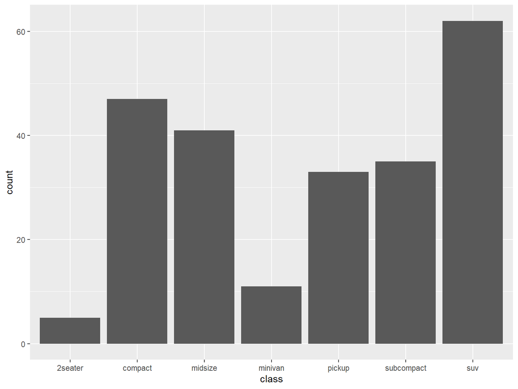

```r
# no y mapping needed when creating a bar chart
ggplot(mpg, aes(x = class)) +
  geom_bar()
```

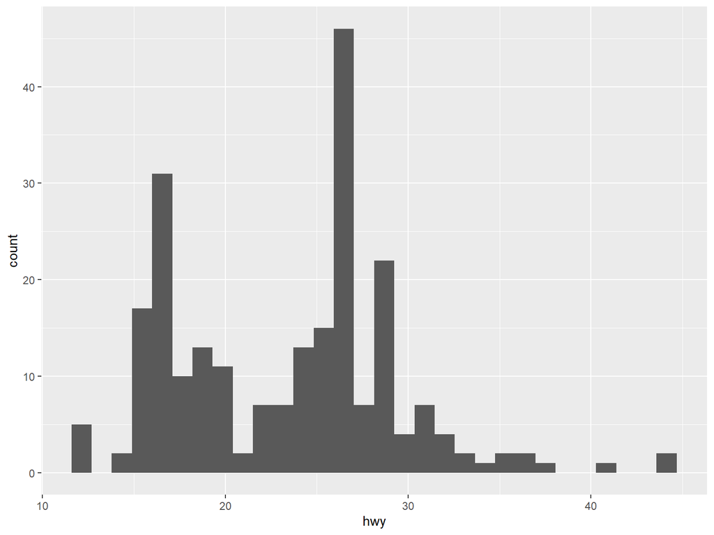

```r
ggplot(mpg, aes(x = hwy)) +
  geom_histogram()
```

What makes this really powerful is that you can add multiple geometries to a plot, thus allowing you to create complex graphics showing multiple aspects of your data.

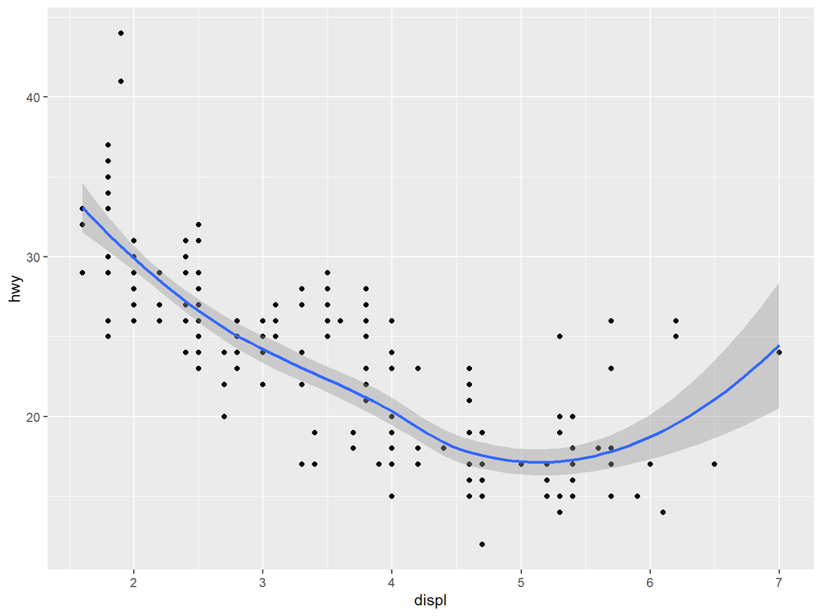

```r
# plot with both points and smoothed line
ggplot(mpg, aes(x = displ, y = hwy)) +
  geom_point() +
  geom_smooth()
```

**Note:** 1. Since the aesthetics for each geom can be different, we could show multiple lines on the same plot (or with different colors, styles, etc).

For example, we can plot both points and a smoothed line for the same x and y variable but specify unique colors within each geom:

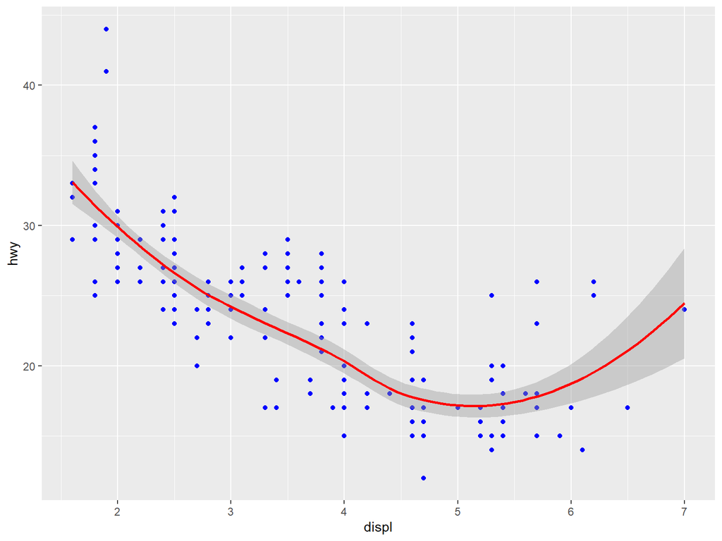

```r
ggplot(mpg, aes(x = displ, y = hwy)) +
  geom_point(color = "blue") +
  geom_smooth(color = "red")
```

2. It is also possible to give each geom a different data argument, so that we can show multiple data sets in the same plot.

If we specify an aesthetic within ggplot(), it will be passed on to each geom that follows. Or we can specify certain aes within each geom, which allows us to only show certain characteristics for that specific layer (i.e. geom_point).

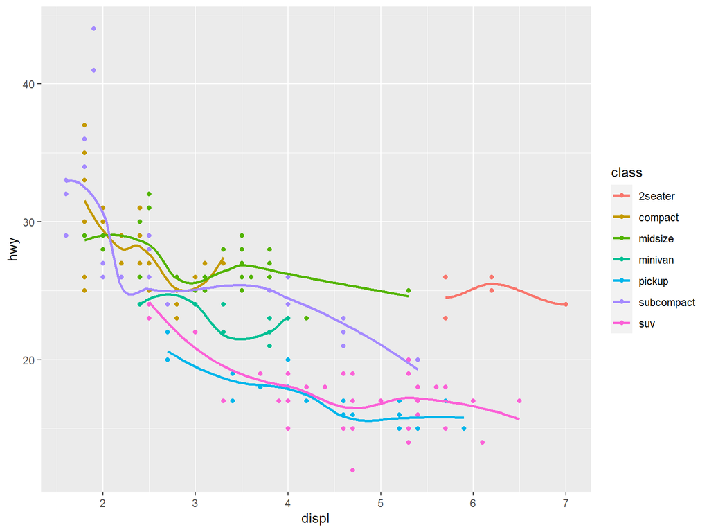

```r
# color aesthetic passed to each geom layer
ggplot(mpg, aes(x = displ, y = hwy, color = class)) +
  geom_point() +
  geom_smooth(se = FALSE)
```

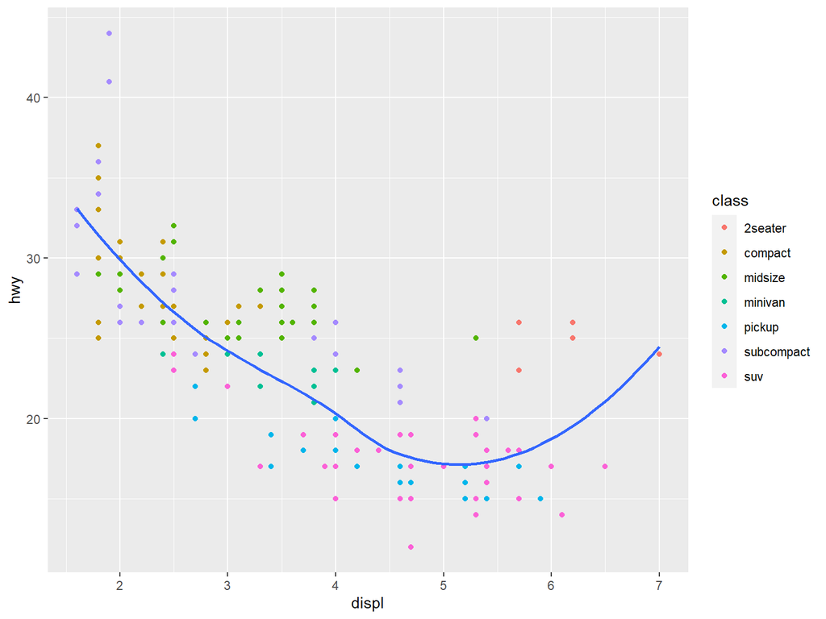

```r
# color aesthetic specified for only the geom_point layer
ggplot(mpg, aes(x = displ, y = hwy)) +
  geom_point(aes(color = class)) +
  geom_smooth(se = FALSE)
```

Exercises:

1. What geom would you use to draw a line chart? A boxplot? A histogram?
2. Create a boxplot of the highwya mileage (hwy).

# Statistical Transformations

The following bar chart shows the frequency distribution of vehicle class. We can find that y axis was defined as the count of elements that have the particular type. This count is not part of the data set, but is instead a statistical transformation that the geom_bar automatically applies to the data. In particular, it applies the stat_count transformation.

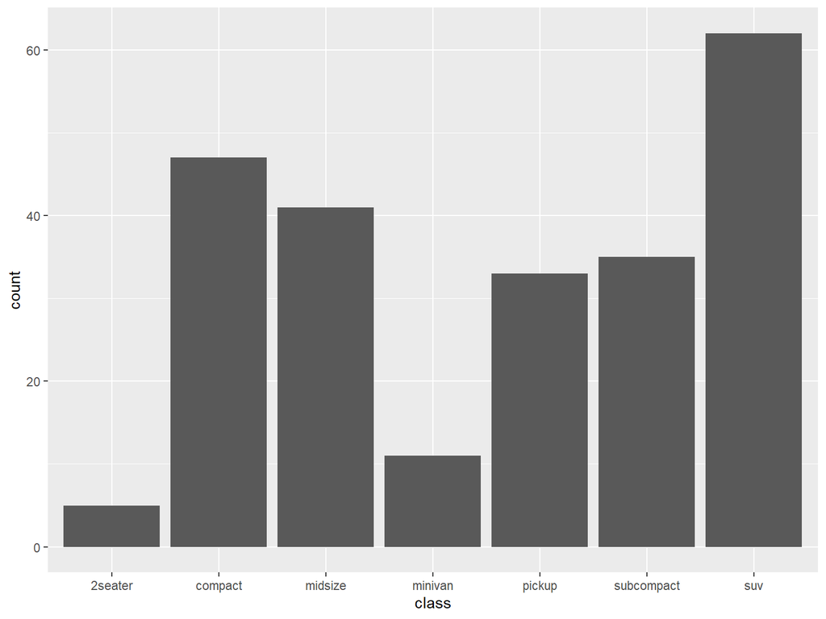

```r
ggplot(mpg, aes(x = class)) +
  geom_bar()
```

ggplot2 supports many different statistical transformations. For example, the “identity” transformation will leave the data “as is.” We can specify which statistical transformation a geom uses by passing it as the stat argument. For example, consider our data already had the count as a variable:

```r
(class_count <- count(mpg, class))
```

```
## # A tibble: 7 x 2
##   class          n
##   <chr>      <int>
## 1 2seater        5
## 2 compact       47
## 3 midsize       41
## 4 minivan       11
## 5 pickup        33
## 6 subcompact    35
## 7 suv           62
```

We can use stat = “identity” within geom_bar to plot our bar height values to this variable. Also, note that we now include n for our y variable:

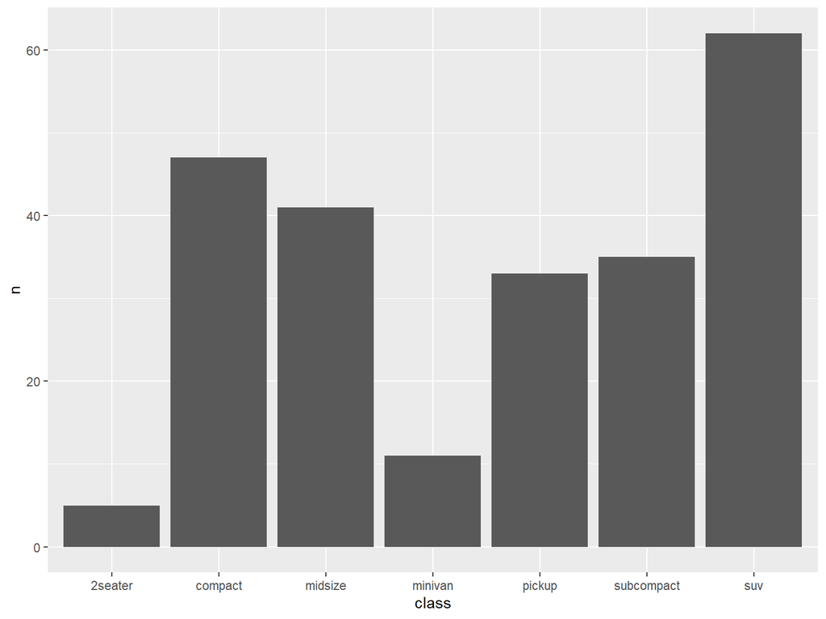

```r
ggplot(class_count, aes(x = class, y = n)) +
  geom_bar(stat = "identity")
```

We can also call stat_ functions directly to add additional layers. For example, here we create a scatter plot of highway miles for each displacement value and then use stat_summary() to plot the mean highway miles at each displacement value.

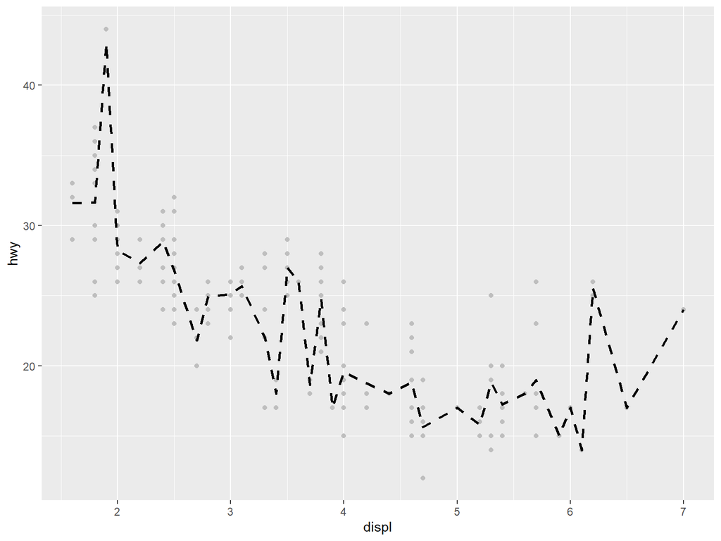

```r
ggplot(mpg, aes(displ, hwy)) +
  geom_point(color = "grey") +
  stat_summary(fun.y = "mean", geom = "line", size = 1, linetype = "dashed")
```

Exercises:

1. What is the default geom associated with stat_summary()?
2. What variables does stat_smooth()compute? What parameters control its behavior?

# Position Adjustments

In addition to a default statistical transformation, each geom also has a default position adjustment which specifies a set of “rules” as to how different components should be positioned relative to each other. This position is noticeable in geom_bar() if we map a different variable to the color visual characteristic.

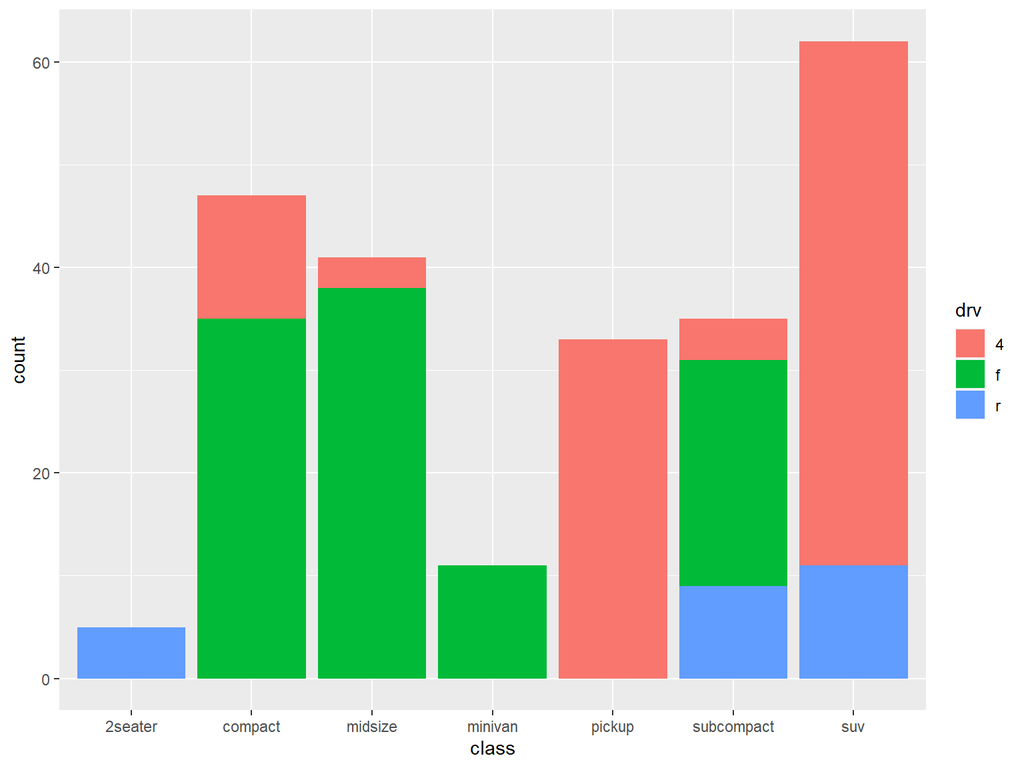

```r
# bar chart of class, colored by drive (front, rear, 4-wheel)
ggplot(mpg, aes(x = class, fill = drv)) +
  geom_bar()
```

The geom_bar() by default uses a position adjustment of “stack,” which makes each rectangle’s height proprotional to its value and stacks them on top of each other. We can use the position argument to specify what position adjustment rules to follow:

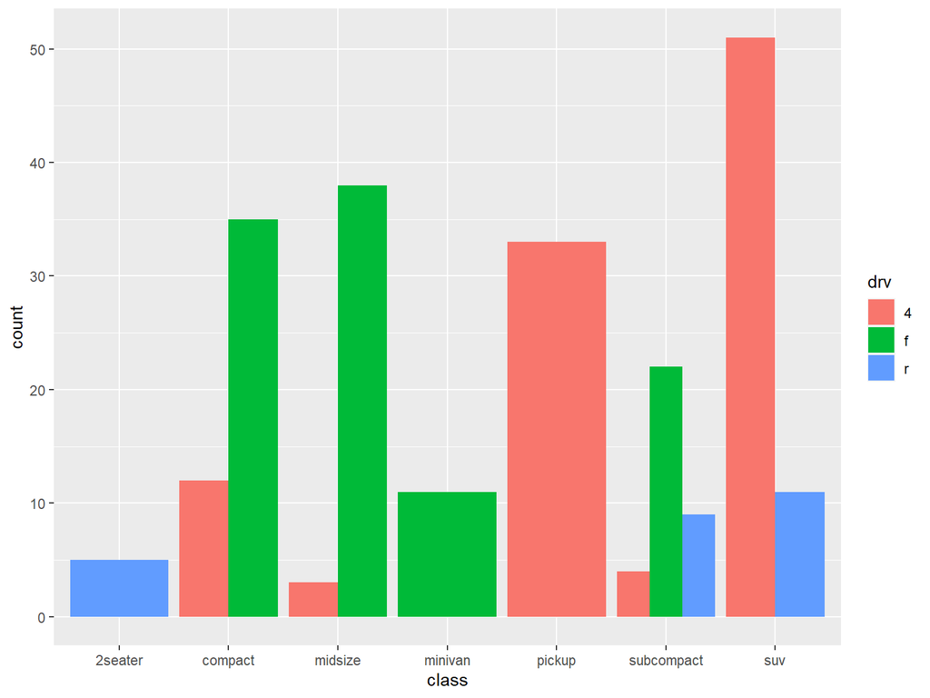

```r
# position = "dodge": values next to each other
ggplot(mpg, aes(x = class, fill = drv)) +
  geom_bar(position = "dodge")
```

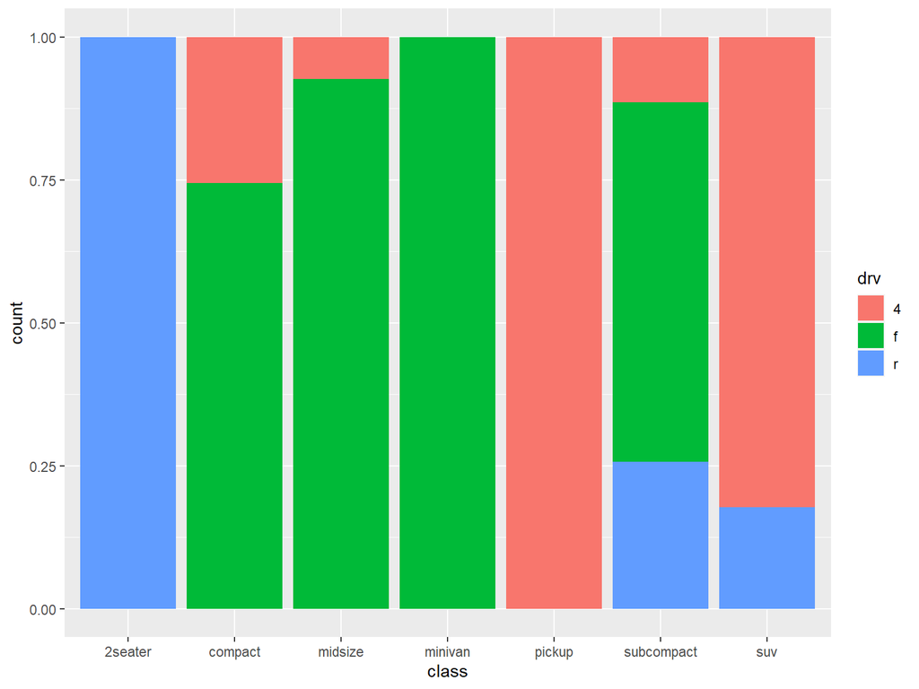

```r
# position = "fill": percentage chart
ggplot(mpg, aes(x = class, fill = drv)) +
  geom_bar(position = "fill")
```

**Note:** We may need to check the documentation for each particular geom to learn more about its positioning adjustments.

# Managing Scales

Whenever we specify an aesthetic mapping, ggplot() uses a particular **scale** to determine the range of values that the data should map to. It automatically adds a scale for each mapping to the plot.

```r
# color the data by engine type
ggplot(mpg, aes(x = displ, y = hwy, color = class)) +
  geom_point()
```

[output not shown]

However, the sclae used in the figure could be changed if needed. Each scale can be represented by a function with the following name: **scale_**, followed by the name of the aesthetic property, followed by an _ and the name of the scale. A continuous scale will handle things like numeric data, whereas a discrete scale will handle things like colors.

```r
# same as above, with explicit scales
ggplot(mpg, aes(x = displ, y = hwy, color = class)) +
  geom_point() +
  scale_x_continuous() +
  scale_y_continuous() +
  scale_colour_discrete()
```

[output not shown]

While the default scales will work fine, it is possible to explicitly add different scales to replace the defaults. For example, we can use a scale to change the direction of an axis:

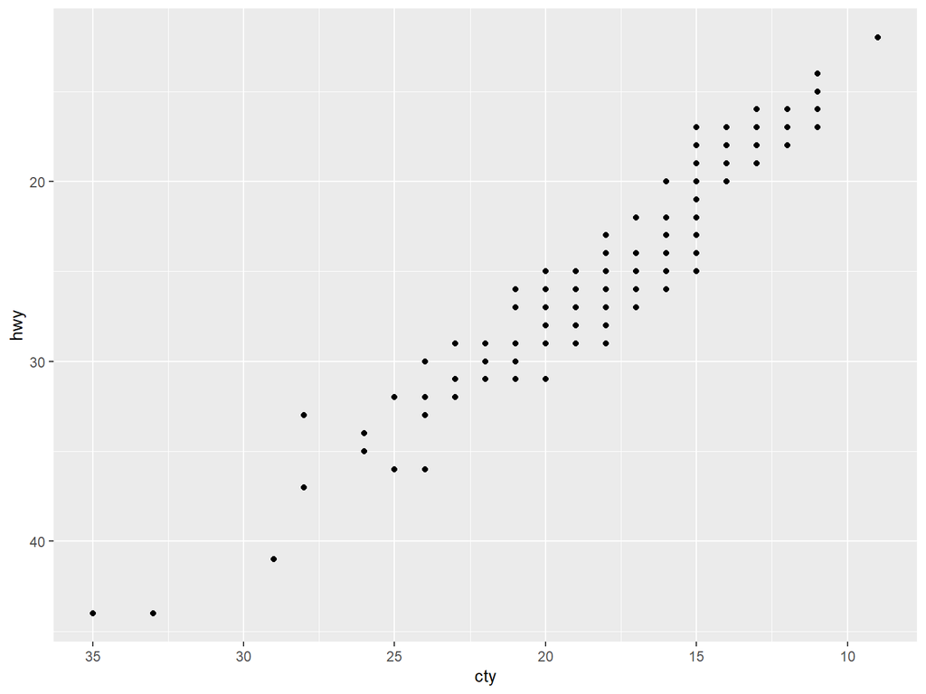

```r
# milage relationship, ordered in reverse
ggplot(mpg, aes(x = cty, y = hwy)) +
  geom_point() +
  scale_x_reverse() +
  scale_y_reverse()
```

Similarly, we can use scale_x_log10() and scale_x_sqrt() to transform the scale. We can use scales to format the axes as well.

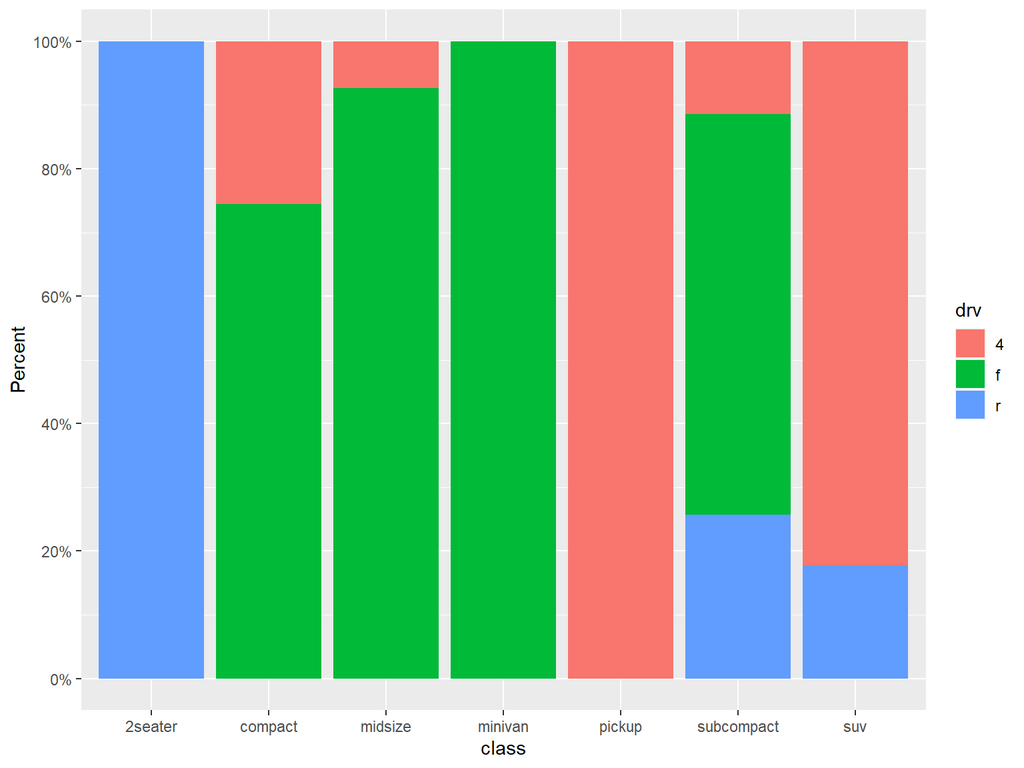

```r
ggplot(mpg, aes(x = class, fill = drv)) +
  geom_bar(position = "fill") +
  scale_y_continuous(breaks = seq(0, 1, by = .2),
                     labels = scales::percent) +
  labs(y = "Percent")
```

# Use Pre-Defined Palettees

A common parameter to change is which set of colors to use in a plot. While you can use the default coloring, a more common option is to leverage the pre-defined palettes from [colorbrewer.org](https://colorbrewer2.org/#type=sequential&scheme=BuGn&n=3). These color sets have been carefully designed to look good and to be viewable to people with certain forms of color blindness. We can leverage color brewer palletes by specifying the scale_color_brewer(), passing the pallete as an argument.

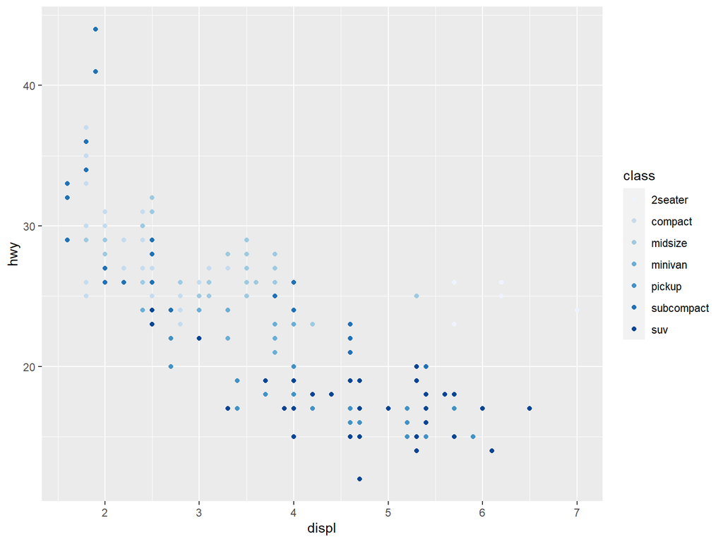

```r
# default color brewer
ggplot(mpg, aes(x = displ, y = hwy, color = class)) +
  geom_point() +
  scale_color_brewer()
```

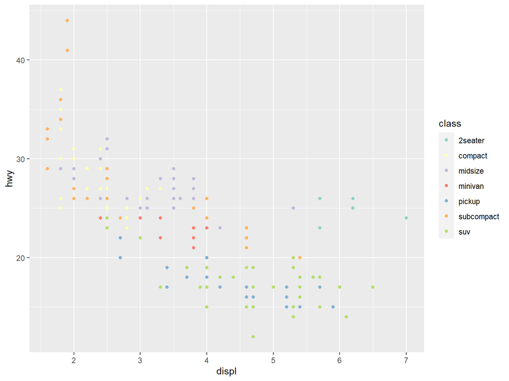

```r
# specifying color palette
ggplot(mpg, aes(x = displ, y = hwy, color = class)) +
  geom_point() +
  scale_color_brewer(palette = "Set3")
```

# Coordinate Systems

Similar to scales, coordinate systems are specified with functions that all start with **coord_** and are added as a layer. There are a number of different possible coordinate systems to use, including:

- coord_cartesian: the default Cartesian coordinate system, where you specify x and y values
- coord_flip: a cartesian system with the x and y flipped
- coord_fixed: a cartesian system with a “fixed” aspect ratio
- coord_polar: a plot using polar coordinates
- coord_quickmap: a coordinate system that approximates a good aspect ratio for maps.

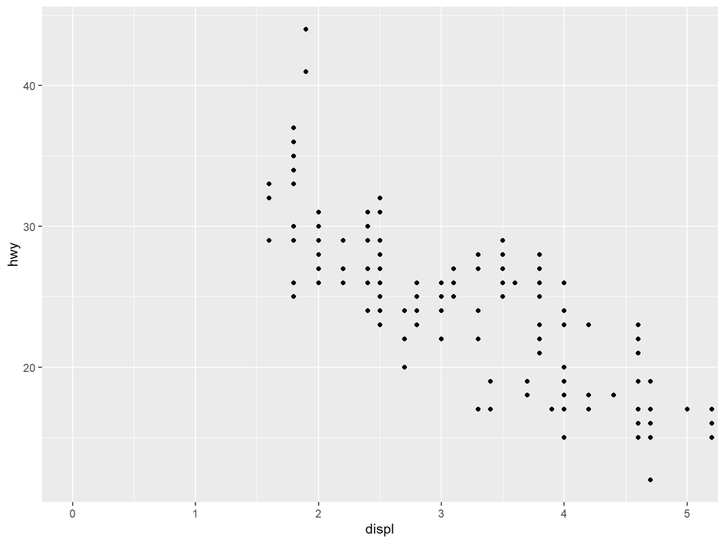

```r
# zoom in with coord_cartesian
ggplot(mpg, aes(x = displ, y = hwy)) +
  geom_point() +
  coord_cartesian(xlim = c(0, 5))
```

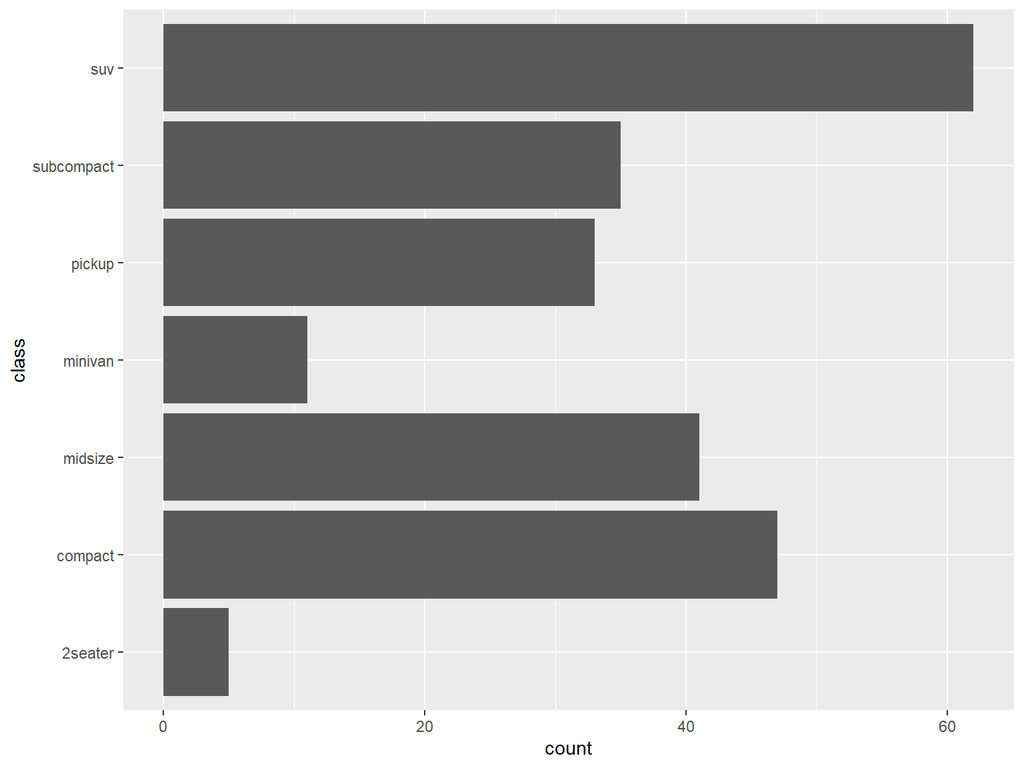

```r
# flip x and y axis with coord_flip
ggplot(mpg, aes(x = class)) +
  geom_bar() +
  coord_flip()
```

# Facets

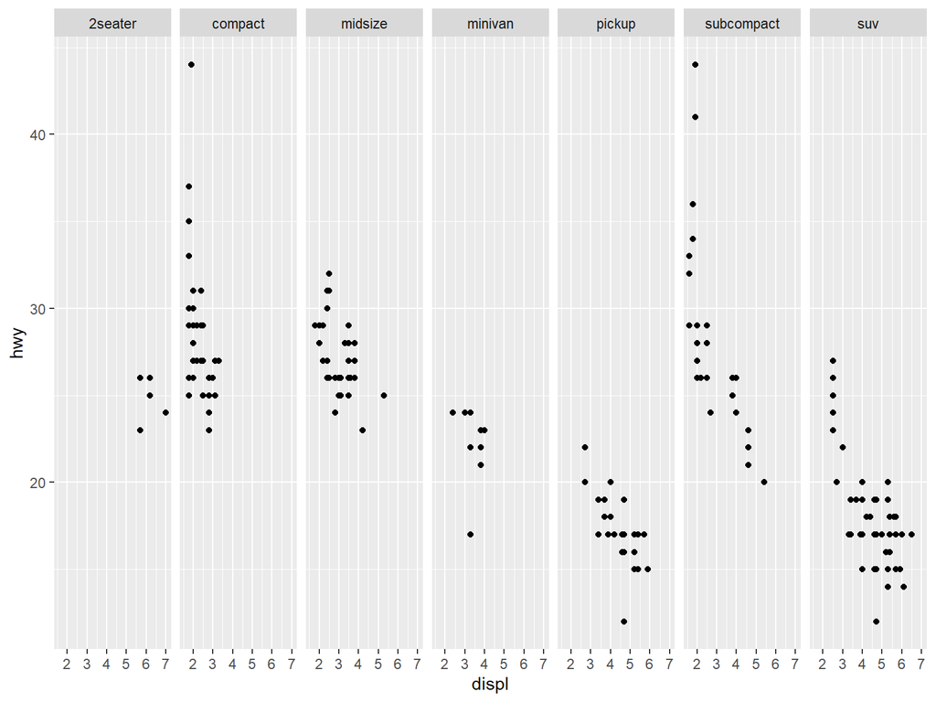

```r
ggplot(mpg, aes(x = displ, y = hwy)) +
  geom_point() +
  facet_grid(~ class)
```

**NOte:** 1. We can facet_grid() to facet the data by more than one categorical variable. 2. We use a tilde (~) in our facet functions. With facet_grid() the variable to the left of the tilde will be represented in the rows and the variable to the right will be represented across the columns.

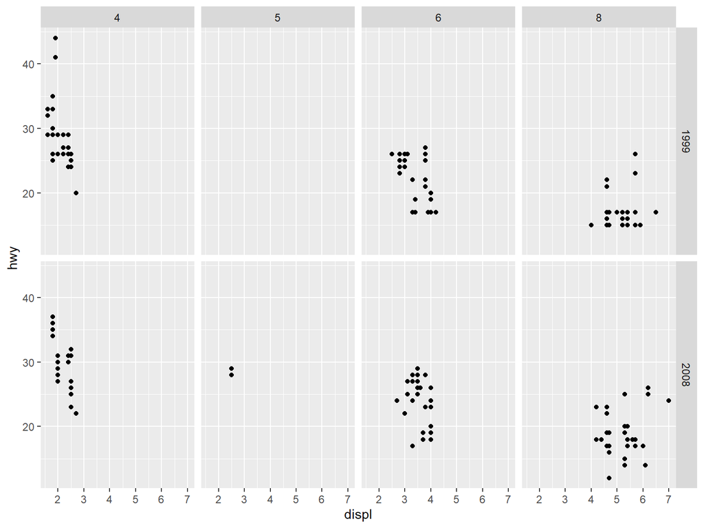

```r
ggplot(mpg, aes(x = displ, y = hwy)) +
  geom_point() +
  facet_grid(year ~ cyl)
```

Exercises:

1. Create a figure of multiple boxplots of the highway mileage (hwy) by the drive type (drv).

# Labels & Annotations

Textual annotations and labels (on the plot, axes, geometry, and legend) are crucial for understanding and presenting information.

- labs: assign title, subtitile, caption, x & y labels

We can add titles and axis labels to a chart using the labs() function (not labels, which is a different R function!).

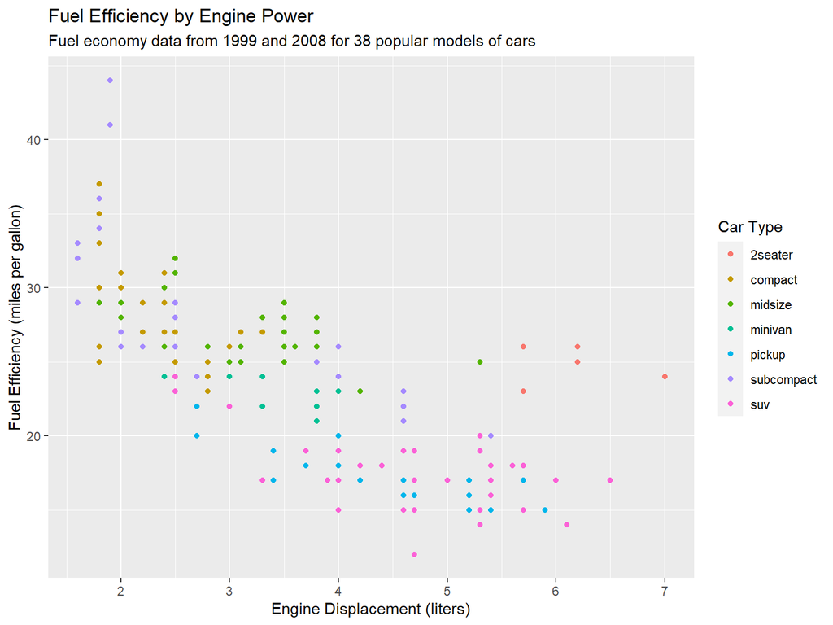

```r
ggplot(mpg, aes(x = displ, y = hwy, color = class)) +
  geom_point() +
  labs(title = "Fuel Efficiency by Engine Power",
       subtitle = "Fuel economy data from 1999 and 2008 for 38 popular models of cars",
       x = "Engine Displacement (liters)",
       y = "Fuel Efficiency (miles per gallon)",
       color = "Car Type")
```

It is also possible to add labels into the plot itself (e.g., to label each point or line) by adding a new geom_text or geom_label to the plot; effectively, we are plotting an extra set of data which happen to be the variable names.

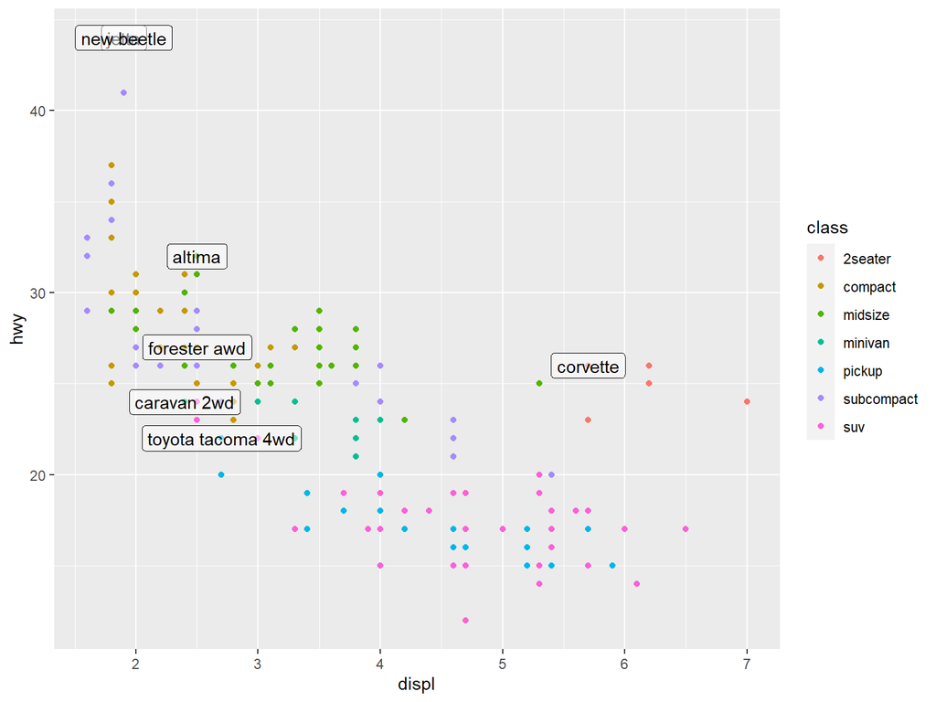

```r
# a data table of each car that has best efficiency of its type

best_in_class <- mpg %>%
  group_by(class) %>%
  filter(row_number(desc(hwy)) == 1)

ggplot(mpg, aes(x = displ, y = hwy)) +
  geom_point(aes(color = class)) +
  geom_label(data = best_in_class, aes(label = model), alpha = 0.5)
```

However, we can find that two labels overlap one-another in the top left part of the plot. We can use the geom_text_repel() from the ggrepel package to help position labels.

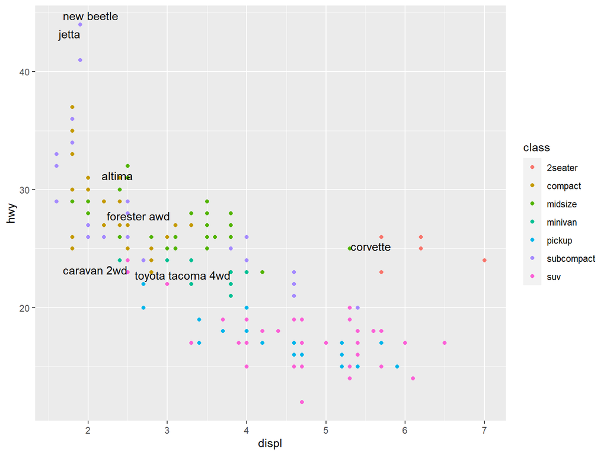

```r
library(ggrepel)

ggplot(mpg, aes(x = displ, y = hwy)) +
  geom_point(aes(color = class)) +
  geom_text_repel(data = best_in_class, aes(label = model))
```

# Themes

Whenever we want to customize titles, labels, fonts, background, grid lines, and legends, we can use themes.

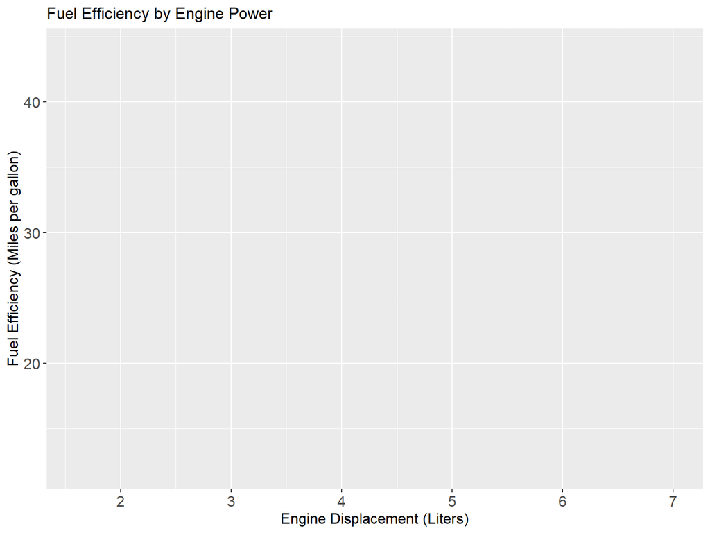

```r
ggplot(mpg, aes(x=displ, y=hwy)) +
  labs(title = "Fuel Efficiency by Engine Power",
       x = "Engine Displacement (Liters)",
       y = "Fuel Efficiency (Miles per gallon)") +
  theme(axis.text.x = element_text(size = 12),
        axis.text.y = element_text(size = 12),
        axis.title.x = element_text(size = 12),
        axis.title.y = element_text(size = 12))
```

**Note:**

1. We only list some key components here.
2. See [Modify Components of A Theme](https://ggplot2.tidyverse.org/reference/theme.html) and [Complete Themes](https://ggplot2.tidyverse.org/reference/ggtheme.html) for more details about the use of theme.

Wickham, Hadley, and Garrett Grolemund. 2016. *R for Data Science: Import, Tidy, Transform, Visualize, and Model Data*. " O’Reilly Media, Inc.".

Xie, Yihui, Joseph J Allaire, and Garrett Grolemund. 2018. *R Markdown: The Definitive Guide*. CRC Press.